# Calibration of Google Trends Time Series

This script produces all results of the following paper:

Robert West. **Calibration of Google Trends Time Series.** In *Proceedings of the 29th ACM International Conference on Information and Knowledge Management (CIKM)*. 2020. [[PDF](https://arxiv.org/abs/2007.13861)]

Note that, whereas the results in the paper were produced with an R implementation, we have since switched over to Python. The R implementation used in this script is not updated anymore. If you are interested in using Google Trends Anchor Bank (G-TAB) in your own research, please instead use the Python implementation available at https://github.com/epfl-dlab/GoogleTrendsAnchorBank.

# Load libraries and define functions and global variables

```r
library(boot)
library(plotrix)

# Root directory of the GitHub repo.
BASE_DIR <- sprintf('%s/github/GoogleTrendsAnchorBank', Sys.getenv('HOME'))

# Load the functions for constructing the anchor bank.
source(sprintf('%s/cikm2020_paper/src/R/g-tab.R', BASE_DIR))
# Set this to FALSE if you don't want to save plots to PDFs.
SAVE_PLOTS <- FALSE

PLOT_DIR <- sprintf('%s/cikm2020_paper/plots', BASE_DIR)

colorblind_col <- c("#000000", "#E69F00", "#56B4E9", "#D55E00", "#009E73", "#0072B2", "#CC79A7", "#F0E442")

config <- DEFAULT_CONFIG
# During binary search, sleep for 1 sec between queries.
config$sleep <- 1

# The threshold used for deciding when to stop the binary search. As derived in the appendix of
# the paper, THRESH=e would be ideal, but we use THRESH=10, since this is the value that was used
# to obtain the results in the paper.
THRESH <- 10

# Load entities from Freebase Easy HTML result page.
get_entities_from_html <- function(file) {
  html <- paste(readLines(file), collapse="\n")
  chunks <- strsplit(html, 'http://www.freebase.com')[[1]]
  pairs <- sapply(chunks, function(s) sub('^(/m/.*?)" target="_blank">(.*?)</a>.*', '\\1###\\2', s))
  names(pairs) <- NULL
  pairs <- pairs[startsWith(pairs, '/m/')]
  pairs <- do.call(rbind, strsplit(pairs, '###'))
  mids_to_names <- pairs[,2]
  names(mids_to_names) <- pairs[,1]
  mids_to_names
}

# Helper function for running binary search on a set of queries.
run_binsearch <- function(dataset, mids_to_names, anchor_bank, thresh, N, K) {
  mids <- names(mids_to_names)
  samples <- mids[seq(1, N, N/K)]
  file <- sprintf('%s/binsearch/%s/results.thresh=%d.N=%d.K=%d.RData', DATA_DIR, dataset, thresh, N, K)
  if (file.exists(file)) {
    load(file)
  } else {
    results <- NULL
    failed <- NULL
    i <- 0
    for (mid in samples) {
      i <- i + 1
      message(sprintf('%d: %s (%s)', i, mid, mids_to_names[mid]))
      b <- binsearch(mid, anchor_bank, thresh, config)
      if (!is.null(b)) results[[mid]] <- b
      else failed <- c(failed, mid)
    }
    save(results, failed, file=file)
  }
  iter <- sapply(results, function(x) x$iter)
  ts <- sapply(results, function(x) x$ts)
  ratio <- sapply(results, function(x) x$ratio)
  return(list(iter=iter, ts=ts, ratio=ratio, failed=failed))
}

# Helper function for bootstrapping 95% CIs.
bootstrap_ci <- function(x, f, R=1000) {
  bo <- boot(x, statistic=function(d, i) return(f(d[i], na.rm=TRUE)), R=R)
  ci <- boot.ci(bo, conf=0.95, type="perc")$perc[4:5]
  if (is.null(ci)) {
    upper <- lower <- NA
  } else {
    lower <- ci[1]
    upper <- ci[2]
  }
  c(upper, f(x, na.rm=TRUE), lower)
}
```

# Build the anchor bank

```r
ab <- build_anchor_bank(config)
G <- ab$G
ts <- ab$time_series
ref_anchor <- ab$ref_anchor
median_anchor <- ab$median_anchor
anchor_bank <- ab$anchor_bank
anchor_bank_hi <- ab$anchor_bank_hi
anchor_bank_lo <- ab$anchor_bank_lo
anchor_bank_init <- sort(ab$W0[ref_anchor,], decreasing=TRUE)
```

# Visualize the initial and optimized anchor banks

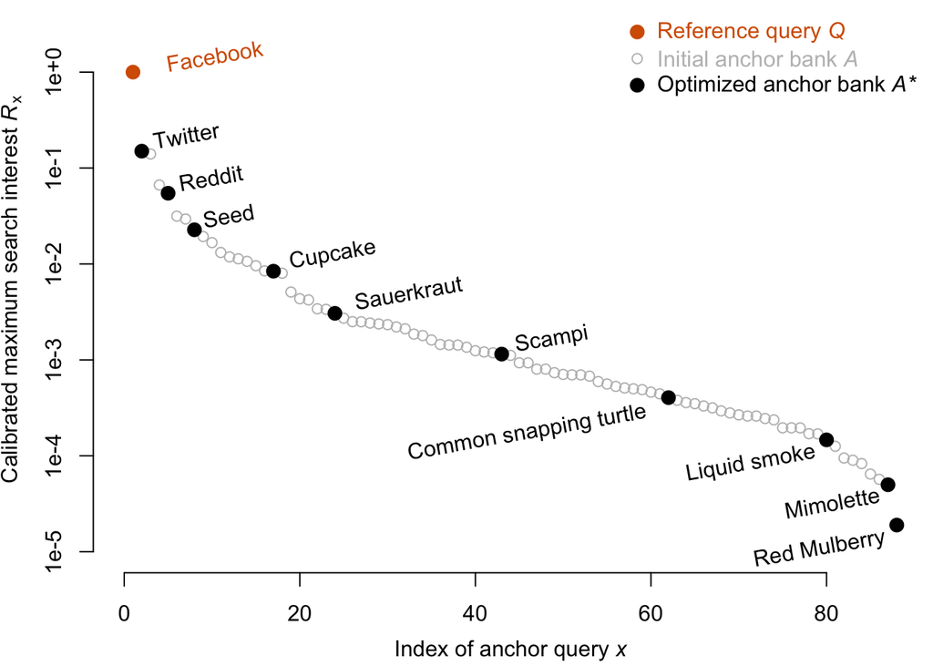

```r
if (SAVE_PLOTS) cairo_pdf(sprintf('%s/anchor_bank.pdf', PLOT_DIR), width=3.4, height=3.25, pointsize=6,
                          family='Helvetica')
col_ref <- colorblind_col[4]
col_opt <- 'black'
col_init <- 'gray'
y <- anchor_bank_init
par(mar=c(3.5, 3.5, 0.2, 0.2))
plot(y, log='y', xlab='', ylab='', bty='n', lwd=1, col=col_init, axes=FALSE, xlim=c(0, length(y)), ylim=c(1e-5, 3))
axis(1)
mtext(expression(paste('Index of anchor query ', italic(x))), side=1, line=2.5)
ticks <- 10^(-5:0)
axis(2, at=ticks, labels=sprintf('1e%s', c(-(5:1), '+0')))
mtext(expression(paste('Calibrated maximum search interest ', italic(R)[x])), side=2, line=2.5)
# Reference query.
points(1, 1, pch=20, col=col_ref, cex=2)
text(5, 1, mid2name(names(y[1])), adj=c(0,0), col=col_ref, srt=10)
# Optimized anchor bank
idx <- which(names(anchor_bank_init) %in% names(anchor_bank))[-1] # -1 to remove the ref query
yy <- y[idx]
points(idx, yy, pch=20, col='black', cex=2)
idx1 <- idx[1:6]
text(idx1, y[idx1], mid2name(names(y[idx1])), adj=c(-0.2, 0), srt=10)
idx2 <- idx[7:10]
text(idx2, y[idx2], mid2name(names(y[idx2])), adj=c(1.1, 1), srt=10)
# Legend
col <- c(col_ref, col_init, col_opt)
legend('topright', legend=c(expression(paste('Reference query ', italic(Q))),
                            expression(paste('Initial anchor bank ', italic(A))),
                            expression(paste('Optimized anchor bank ', italic(A), '*'))),
       bty='n', pch=c(20,1,20), pt.cex=c(2,1,2), col=col, text.col=col)
```

```r
if (SAVE_PLOTS) dev.off()
```

# Test the binary search

```
##    Comparing to /m/02s3cz (Scampi)
```

```
##    Going lower
```

```
##    Comparing to /m/04xmxz (Liquid smoke)
```

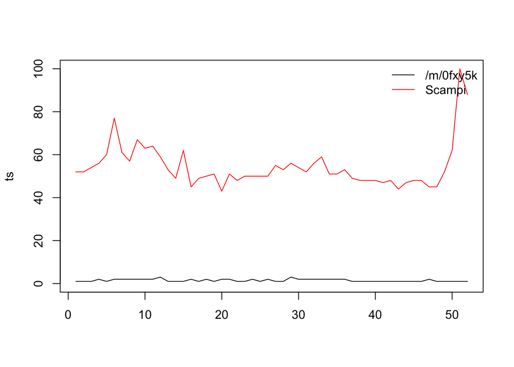

```
## Done with /m/0fxy5k after 2 steps
```

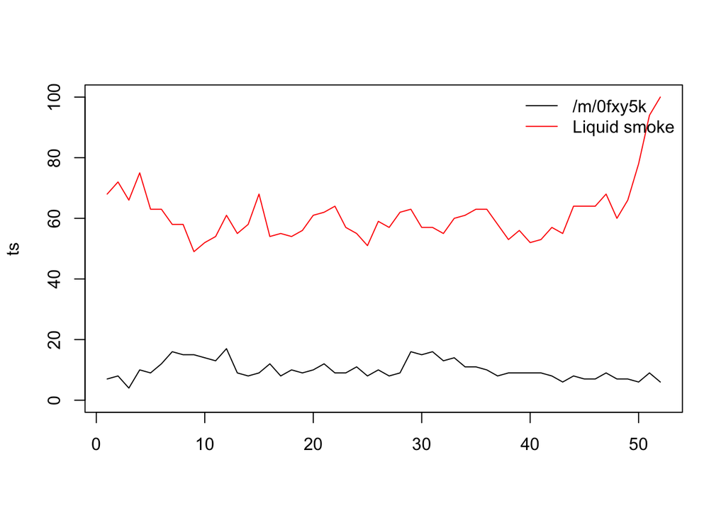

```r
# Jever
b <- binsearch('/m/0fxy5k', anchor_bank, anchor_bank_hi, anchor_bank_lo, config,
               first_comparison=median_anchor, thresh=THRESH, plot=TRUE, quiet=FALSE)
```

```
##    Comparing to /m/02s3cz (Scampi)
```

```
##    Going higher
```

```
##    Comparing to /m/0b2334 (Reddit)
```

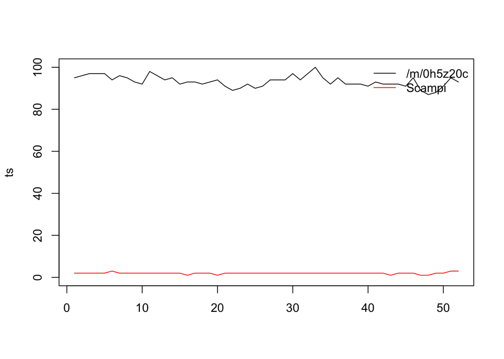

```
## Done with /m/0h5z20c after 2 steps
```

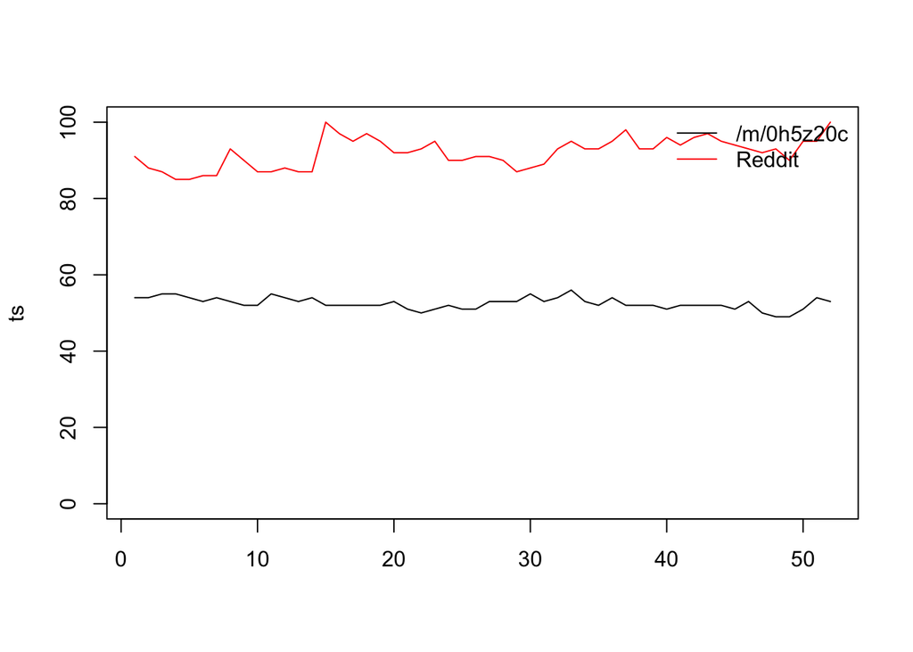

```r
# Audi
b <- binsearch('/m/0h5z20c', anchor_bank, anchor_bank_hi, anchor_bank_lo, config,
               first_comparison=median_anchor, thresh=THRESH, plot=TRUE, quiet=FALSE)
```

```
##    Comparing to /m/02s3cz (Scampi)
```

```
## Done with /m/06pwq after 1 steps
```

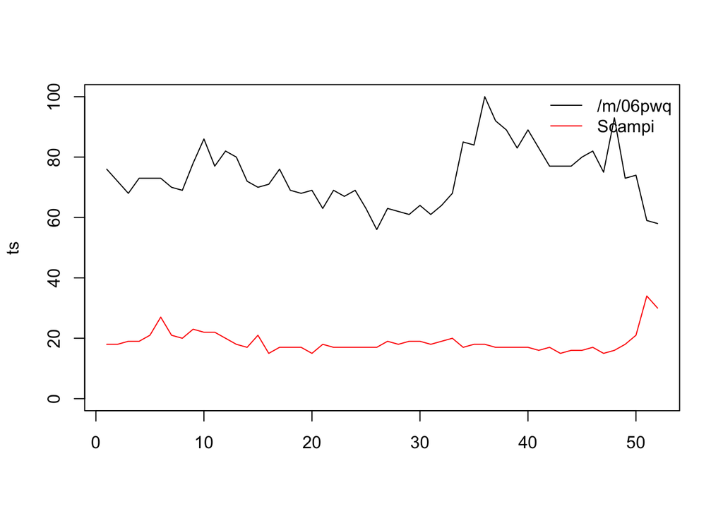

```r
# Stanford University
b <- binsearch('/m/06pwq', anchor_bank, anchor_bank_hi, anchor_bank_lo, config,
               first_comparison=median_anchor, thresh=THRESH, plot=TRUE, quiet=FALSE)
```

Plot the time series for the last query with upper and lower bounds, based on the largest possible (unknown) rounding errors.

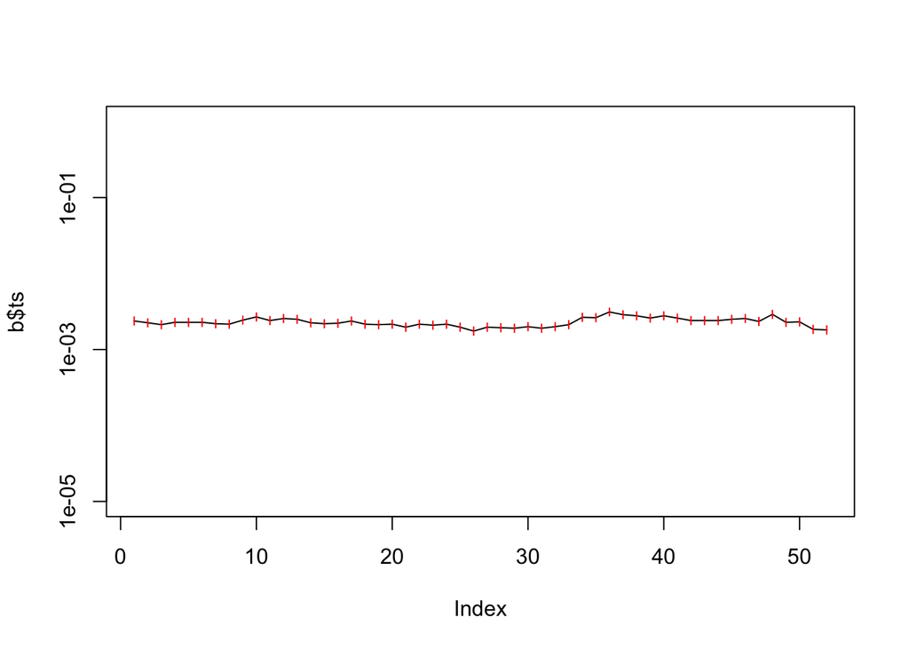

```r
# Plot upper and lower bounds.
plot(b$ts, type='l', log='y', ylim=c(1e-5,1))
dispersion(1:length(b$ts), b$ts, b$ts_hi, b$ts_lo, intervals=FALSE, arrow.gap=0, arrow.cap=0, col='red')
```

# Example results

## Example 1: Bavarian towns

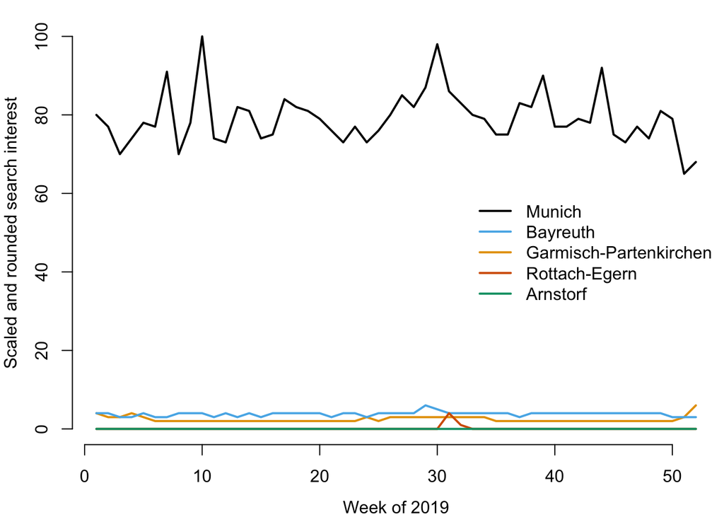

```r
# Note: these results were produced using the initial anchor bank, before optimizing it as
# described in Appendix A of the CIKM'20 paper.
abank <- anchor_bank_init

dataset <- 'bavaria'
mids_to_names <- get_entities_from_html(sprintf('%s/binsearch/%s/freebase_easy_%s.html',
                                                DATA_DIR, dataset, dataset))
mid_arnstorf <- '/m/02rg8rj'
mids_to_names[mid_arnstorf] <- 'Arnstorf'
names_to_mids <- names(mids_to_names)
names(names_to_mids) <- mids_to_names

highlights <- names_to_mids[c('Munich', 'Garmisch-Partenkirchen', 'Bayreuth',
                              'Rottach-Egern', 'Arnstorf')]

file <- sprintf('%s/binsearch/%s/results.thresh=%d.ARNSTORF.RData', DATA_DIR, dataset, THRESH)
if (file.exists(file)) {
  load(file)
} else {
  result_arnstorf <- binsearch(mid_arnstorf, abank, THRESH, config)
  save(result_arnstorf, file=file)
}

file <- sprintf('%s/binsearch/%s/results.thresh=%d.HIGHLIGHTS.RData', DATA_DIR, dataset, THRESH)
if (file.exists(file)) {
  load(file)
} else {
  result_highlights <- query_google(highlights, config)
  save(result_highlights, file=file)
}

result1 <- run_binsearch(dataset, mids_to_names, abank, thresh=THRESH, N=100, K=100)
result2 <- run_binsearch(dataset, mids_to_names, abank, thresh=THRESH, N=1000, K=100)
extra_idx <- setdiff(names(result2$iter), names(result1$iter))
ts_bavaria <- cbind(result1$ts, result2$ts[,extra_idx])
iter_bavaria <- c(result1$iter, result2$iter[extra_idx])
ratio_bavaria <- c(result1$ratio, result2$ratio[extra_idx])
ts_bavaria <- cbind(ts_bavaria, result_arnstorf$ts)
colnames(ts_bavaria)[ncol(ts_bavaria)] <- mid_arnstorf
ts_bavaria[,mid_arnstorf] <- result_arnstorf$ts
iter_bavaria[mid_arnstorf] <- result_arnstorf$iter
ratio_bavaria[mid_arnstorf] <- result_arnstorf$ratio

if (SAVE_PLOTS) cairo_pdf(sprintf('%s/timeseries_bavaria_RAW_LINEAR.pdf', PLOT_DIR), width=1.7, height=2,
                          pointsize=6, family='Helvetica')
par(mar=c(3.5, 3.5, 1.0, 0.2))
matplot(result_highlights$ts, type='l', lty=1, log='', col=colorblind_col, lwd=2, bty='n', xlab='', ylab='', axes=FALSE)
axis(1); mtext('Week of 2019', side=1, line=2.5)
axis(2); mtext('Scaled and rounded search interest', side=2, line=2.5)
idx <- c(1,3,2,4,5)
legend('topright', names(highlights)[idx], lty=1, col=colorblind_col[idx], lwd=2, bty='n', inset=c(0,0.4))
```

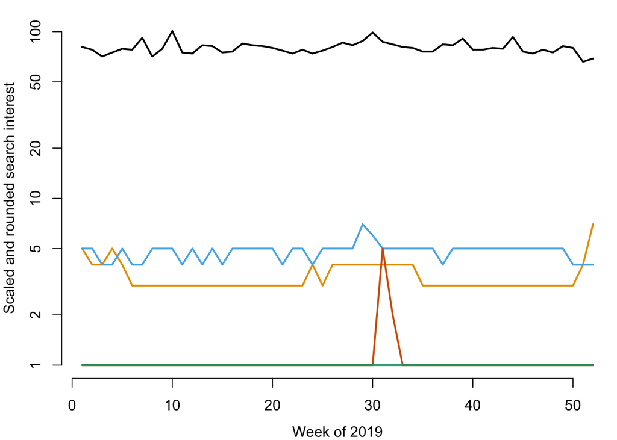

```r
if (SAVE_PLOTS) dev.off()

if (SAVE_PLOTS) cairo_pdf(sprintf('%s/timeseries_bavaria_RAW_LOG.pdf', PLOT_DIR), width=1.7, height=2,
                          pointsize=6, family='Helvetica')
par(mar=c(3.5, 3.5, 1.0, 0.2))
matplot(1+result_highlights$ts, type='l', lty=1, log='y', col=colorblind_col, lwd=2, bty='n', xlab='', ylab='', axes=FALSE)
axis(1); mtext('Week of 2019', side=1, line=2.5)
axis(2); mtext('Scaled and rounded search interest', side=2, line=2.5)
```

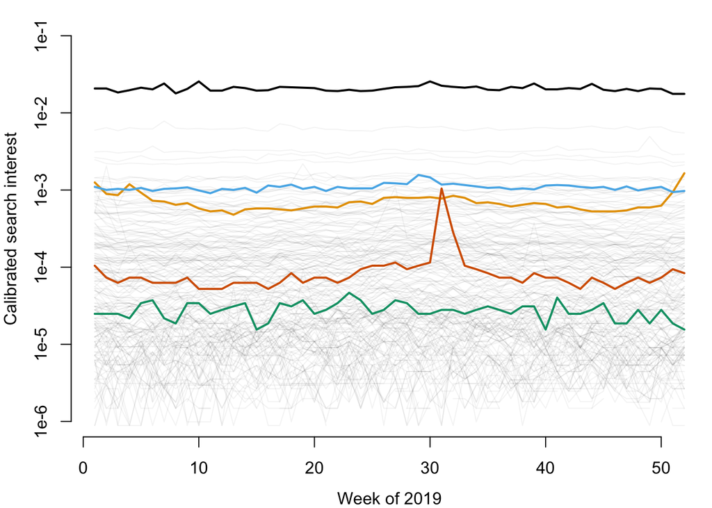

```r
if (SAVE_PLOTS) dev.off()


if (SAVE_PLOTS) cairo_pdf(sprintf('%s/timeseries_bavaria_CALIB.pdf', PLOT_DIR), width=1.7, height=2,
                          pointsize=6, family='Helvetica')
par(mar=c(3.5, 3.5, 1.0, 0.2))
idx <- order(ratio_bavaria, decreasing=TRUE)
matplot(ts_bavaria[,idx], type='l', lty=1, log='y', col=rgb(0,0,0,0.05), lwd=1, bty='n', xlab='', ylab='',
        axes=FALSE, ylim=c(1e-6, 0.1))
ticks <- 10^(-6:-1)
axis(1); mtext('Week of 2019', side=1, line=2.5)
axis(2, at=ticks, labels=sprintf('1e-%d', 6:1)); mtext('Calibrated search interest', side=2, line=2.5)
i <- 0
for (h in highlights) {
  col <- colorblind_col[(i %% length(colorblind_col))+1]
  lines(ts_bavaria[,h], lwd=2, col=col)
  i <- i + 1
}
```

[figure not shown]

```r
if (SAVE_PLOTS) dev.off()


if (SAVE_PLOTS) cairo_pdf(sprintf('%s/search_steps_bavaria.pdf', PLOT_DIR), width=1.7, height=2,
                          pointsize=6, family='Helvetica')
par(mar=c(3.5, 3.5, 0.5, 0.8))
freq <- tapply(iter_bavaria, iter_bavaria, length)
freq <- rev(freq / sum(freq))
barplot(freq, horiz=TRUE, las=1, border=NA, xlim=c(0, 0.5))
mtext('Relative frequency', side=1, line=2.5)
mtext('Google Trends requests per search query', side=2, line=2.5)
legend('bottomright', legend=c(sprintf('Mean: %.2f', mean(iter_bavaria)), sprintf('Median: %s', median(iter_bavaria))),
       bty='n', inset=c(0.1,0.1))
```

```r
if (SAVE_PLOTS) dev.off()
```

## Example 2: Soccer clubs

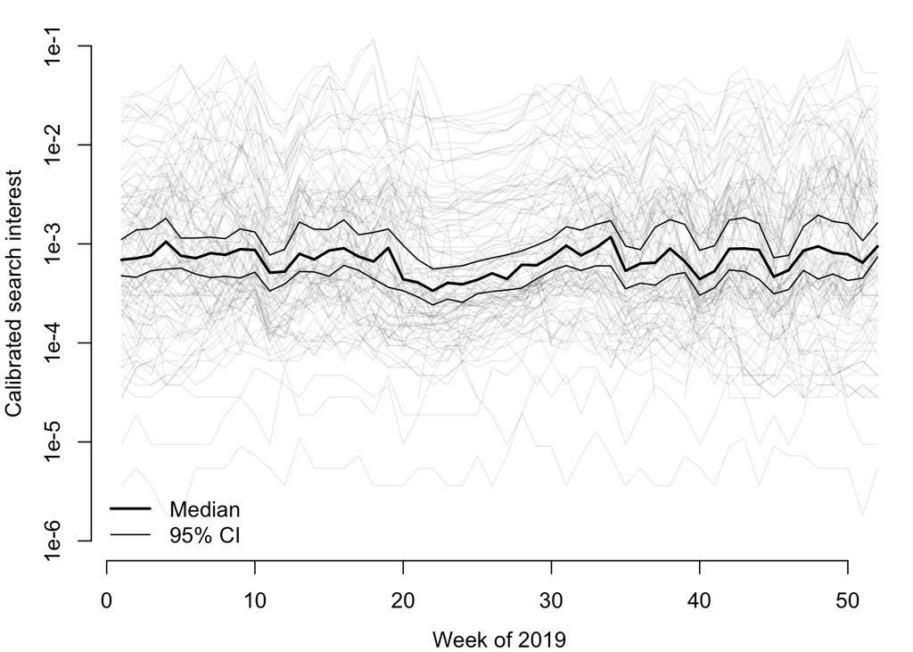

```r
dataset <- 'soccer'
mids_to_names <- get_entities_from_html(sprintf('%s/binsearch/%s/freebase_easy_%s.html', DATA_DIR, dataset, dataset))
result <- run_binsearch(dataset, mids_to_names, abank, thresh=THRESH, N=100, K=100)
ts_soccer <- result$ts
iter_soccer <- result$iter
ratio_soccer <- result$ratio
bs <- apply(ts_soccer, 1, function(x) bootstrap_ci(x,median,1000))

if (SAVE_PLOTS) cairo_pdf(sprintf('%s/timeseries_soccer_CALIB.pdf', PLOT_DIR), width=1.7, height=2,
                          pointsize=6, family='Helvetica')
par(mar=c(3.5, 3.5, 1.0, 0.2))
idx <- order(ratio_soccer, decreasing=TRUE)
matplot(ts_soccer[,idx], type='l', lty=1, log='y', col=rgb(0,0,0,0.08), lwd=1, bty='n', xlab='', ylab='',
        axes=FALSE, ylim=c(1e-6, 0.1))
ticks <- 10^(-6:-1)
axis(1); mtext('Week of 2019', side=1, line=2.5)
axis(2, at=ticks, labels=sprintf('1e-%d', 6:1)); mtext('Calibrated search interest', side=2, line=2.5)
lines(apply(ts_soccer, 1, median), type='l', lwd=2, col=colorblind_col[1])
lines(bs[1,], type='l', lwd=1)
lines(bs[3,], type='l', lwd=1)
legend('bottomleft', legend=c('Median', '95% CI'), lty=1, lwd=c(2,1), bty='n', inset=c(0,0))
```

[figure not shown]

```r
if (SAVE_PLOTS) dev.off()


if (SAVE_PLOTS) cairo_pdf(sprintf('%s/search_steps_soccer.pdf', PLOT_DIR), width=1.7, height=2,
                          pointsize=6, family='Helvetica')
par(mar=c(3.5, 3.5, 0.5, 0.8))
freq <- tapply(iter_soccer, iter_soccer, length)
for (i in as.character(1:5)) if (!(i %in% names(freq))) freq[i] <- 0
freq <- rev(freq / sum(freq))
barplot(freq, horiz=TRUE, las=1, border=NA, xlim=c(0, 0.7))
mtext('Relative frequency', side=1, line=2.5)
mtext('Google Trends requests per search query', side=2, line=2.5)
legend('bottomright', legend=c(sprintf('Mean: %.2f', mean(iter_soccer)), sprintf('Median: %s', median(iter_soccer))),
       bty='n', inset=c(0.1,0.1))
```

```r
if (SAVE_PLOTS) dev.off()
```

# Theoretical analysis

This code supplements the theoretical analysis of the appendix of the CIKM’20 paper.

```r
eps <- 1/200
eta <- function(c, r) ((c+eps)/(c-eps))^(log(r)/log(c))
e <- exp(1)

# Unused.
eta_jagged <- function(c, r) {
  logr <- log(r)/log(c)
  res <- r / c^(ceiling(logr)-1)
  ((c+eps)/(c-eps))^(ceiling(logr)-1) * (res+eps)/(res-eps)
}
```

Plot $\eta(c,r^*)$ as a function of $c$, for various choices of $r^*$.

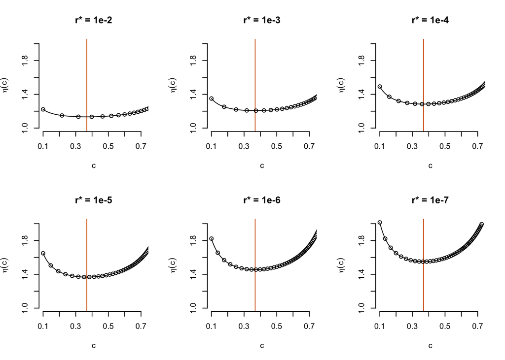

```r
if (SAVE_PLOTS) cairo_pdf(sprintf('%s/eta_as_fct_of_c.pdf', PLOT_DIR), width=3.4, height=3.25,
                          pointsize=6, family='Helvetica')
c <- seq(0.1, 0.72, 0.01)
par(mfrow=c(2,3))
for (r in 0.1^(2:7)) {
  ylim=c(1, max(eta(c,0.1^7)))
  plot(c, eta(c,r), log='', type='l', main=sprintf('r* = 1e%d', log10(r)), ylim=ylim,
       xlab='c', ylab=expression(eta(c)), bty='n',
       panel.first=abline(v=1/e, col=colorblind_col[4]))
  x <- r^(1/(1:50))
  points(x, eta(x,r))
}
```

```r
if (SAVE_PLOTS) dev.off()
```

# Comparison of initial and final anchor banks

As we see, the optimized anchor bank comes much closer to the theoretical lower bound of the bound ratio.

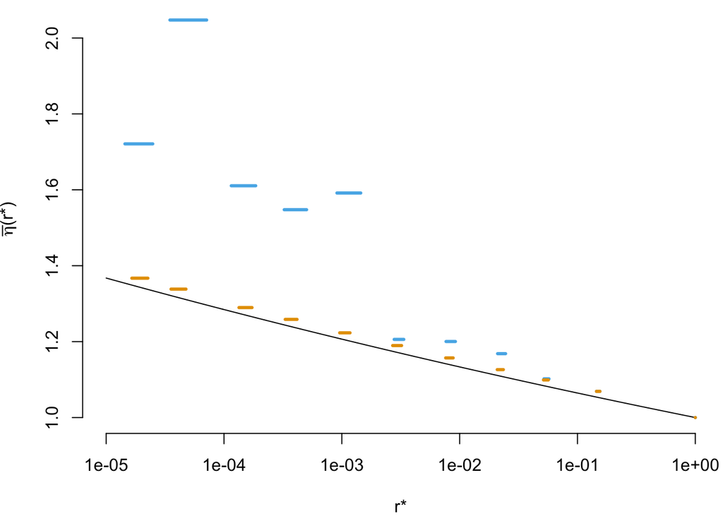

```r
idx <- colnames(ab$W)
W0_hi <- ab$W0_hi[idx,idx]
W0_lo <- ab$W0_lo[idx,idx]
W_hi <- ab$W_hi
W_lo <- ab$W_lo

hi0 <- W0_hi[ref_anchor,]
lo0 <- W0_lo[ref_anchor,]
hi1 <- W_hi[ref_anchor,]
lo1 <- W_lo[ref_anchor,]

if (SAVE_PLOTS) cairo_pdf(sprintf('%s/eta_bar.pdf', PLOT_DIR), width=3.4, height=3.25,
                          pointsize=6, family='Helvetica')
par(mfrow=c(1,1))
par(mar=c(4, 4, 0.2, 0.2))
r_range <- range(c(lo1, lo0, hi1, hi0))
r <- 10^seq(floor(log10(r_range)[1]), 0, 0.01)
plot(r, eta(1/e,r), log='x', type='l', ylim=range(c(eta(1/e,r), hi0/lo0)), lwd=1, col='black',
     axes=FALSE, bty='n', xlab='r*', ylab=expression(paste(bar(eta), "(r*)")))
axis(1, at=10^seq(floor(log10(r_range)[1]), 0))
axis(2)
segments(x0=lo0, y0=hi0/lo0, x1=hi0, col=colorblind_col[3], lwd=3)
segments(x0=lo1, y0=hi1/lo1, x1=hi1, col=colorblind_col[2], lwd=3)
```

```r
if (SAVE_PLOTS) dev.off()
```